# Phd Abroad

Anubhab Biswas

ISAAC, SUPSI

2025-09-23

## Why a PhD?

- Ask yourself - why do you want to pursue a PhD?
- ….or rather if you want to pursue a PhD?
- Usually lower salaries compared to other jobs.
- But, better job opportunities afterwards in a specialized field.
- More flexibility and freedom to expand your knwoledge and apply it.

## Where to do a PhD?

**TOTALLY DEPENDS ON YOU AND YOUR CAREER GOALS !**

## PhD Abroad: USA vs Europe

- **USA**:
  - PhD is 5-6 years
  - Annual deadlines about filling up the application form
  - Work-life balance is better than India, but not the best
  - Mandatory coursework, very good for theoretical works, statistics.
- **Europe**:
  - PhD is 3-4 years
  - Applications are open generally all year round, and they come as job advertisements
  - Work-life balance is unmatched, but more pressure during working hours
  - Coursework could be there but very relaxed, very good for applied work.

## Europe: What to consider?

- PhD is treated as a fixed term employment
- Salaries in our field is generally pretty decent for living here.
- Most of the funding generally comes from the European projects, so aligning the topic of PhD with these projects have a big importance.
- Specialization is the first priority, not outstanding grades.

## Not so academic things to consider

Please be respectful to the local culture!

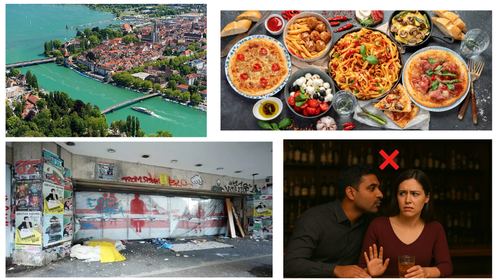

## General Steps to keep in mind

- Having the basics covered
- Identifying the research area
- Boosting your profile
- Motivation / Cover letter
- Interview

## Having the basics covered

- Very crucial
- General topics like distribution theory, statistical inference, optimization need to be conceptually covered.
- It might not be tested during the applications and the interviews.
- But in order to work efficiently and develop research it plays a crucial role.

## Identifying research area + Boosting Profile

- Identify your research area in advance and focus on developing skills there during and after masters.
- Develop your coding skill.
- Those ‘certificate courses’ won’t save you - try to work in the real world scenarios.
- 134 vs 1
  - **134** : number of applications I did and got rejected before or after interview before I started working on a specialized topic after masters and built a research area of expertise.
  - **1** : number of applications I had to do to get accepted after working as a RA.
  - **Lesson learned**: Experience and expertise in a specialized topic is valuable.

## Motivation / Cover Letter + Interview

- Do not write a single word that is out of context and doesn’t align with the position requirement, PhD topic or is not relevant to why you considered this opportunity.
- Never mention any un-published work unless you have a confidence in why it was important or useful.
- Be clear about why you want to do the PhD and why you chose this job opportunity / university. This question will be asked.
- Make sure that your past experiences and skills align with the position and the topic of the PhD - Europe hires people based majorly on this.

## Questions?

- To reach out to me for professional reasons like research collaboration reach out to me at anubhab.biswas@supsi.ch
- For any personal advices or other queries you can write to me in whatsapp.

[figure not shown]

- For queries about doing a PhD in India, you can reach out to my friends (batchmates) via email.
  - Soumya Ghatak, PhD student at Indian Institute of Science (IISc), Bangalore.stat2.5soumya@gmail.com
  - Sreeranjini T M, PhD student at C-MInDS, IIT Bombay. sreeranjini.tm@iitb.ac.in

## Some useful websites

- The following websites are useful for looking into job opportunities in Europe as an aspiring PhD student:
  - [Find a PhD](https://www.findaphd.com/)
  - [Academic Positions](https://academicpositions.com/jobs/position/phd)
  - [Euraxess](https://euraxess.ec.europa.eu/jobs/funding/phd-program)
- Also connect with professors and researchers in your specialized area through linkedIn, X platforms and keep an eye on their profiles for job advertisements.
- Send them an email only if you have a research gap in mind that you want to work on, or an almost clear research question in mind - they are busy so do not send cold unnecessary emails.